# Hernandez_Joe_Assignment1

Team 5: Joe Hernandez

3/31/2019

### Pat Carlin, Pene Seloti, Kenneth McKee, Joe Herndandez

### FIN 654 - Assignment 1

## Part 1: HO2 data preparation and exploration

In this set we will build a data set using filters and if and diff statements. We will then answer some questions using plots and a pivot table report. We will then write a function to house our approach in case we would like to run the same analysis on other data sets.

### Problem

Supply chain managers at our company continue to note we have a significant exposure to heating oil prices (Heating Oil No. 2, or HO2), specifically New York Harbor. The exposure hits the variable cost of producing several products. When HO2 is volatile, so is earnings. Our company has missed earnings forecasts for five straight quarters. To get a handle on HO2 we download this data set and review some basic aspects of the prices.

Loading and cleaning the data in question.

```
##       DATE DHOILNYH
## 1 6/2/1986    0.402
## 2 6/3/1986    0.393
## 3 6/4/1986    0.378
## 4 6/5/1986    0.390
## 5 6/6/1986    0.385
## 6 6/9/1986    0.373
```

```
## 'data.frame':    7697 obs. of  2 variables:
##  $ DATE    : chr  "6/2/1986" "6/3/1986" "6/4/1986" "6/5/1986" ...
##  $ DHOILNYH: num  0.402 0.393 0.378 0.39 0.385 0.373 0.365 0.389 0.394 0.398 ...
```

### Question 1

What is the nature of HO2 returns? We want to reflect the ups and downs of price movements, something of prime interest to management. First, we calculate percentage changes as log returns. Our interest is in the ups and downs. To look at that we use if and else statements to define a new column called direction. We will build a data frame to house this analysis.

```
## 'data.frame':    7696 obs. of  5 variables:
##  $ date     : Date, format: "1986-06-03" "1986-06-04" ...
##  $ price    : num  0.393 0.378 0.39 0.385 0.373 0.365 0.389 0.394 0.398 0.379 ...
##  $ return   : num  -2.26 -3.89 3.13 -1.29 -3.17 ...
##  $ size     : num  2.26 3.89 3.13 1.29 3.17 ...
##  $ direction: Factor w/ 3 levels "down","same",..: 1 1 3 1 1 1 3 3 3 1 ...
```

For visualization we install ggplot2

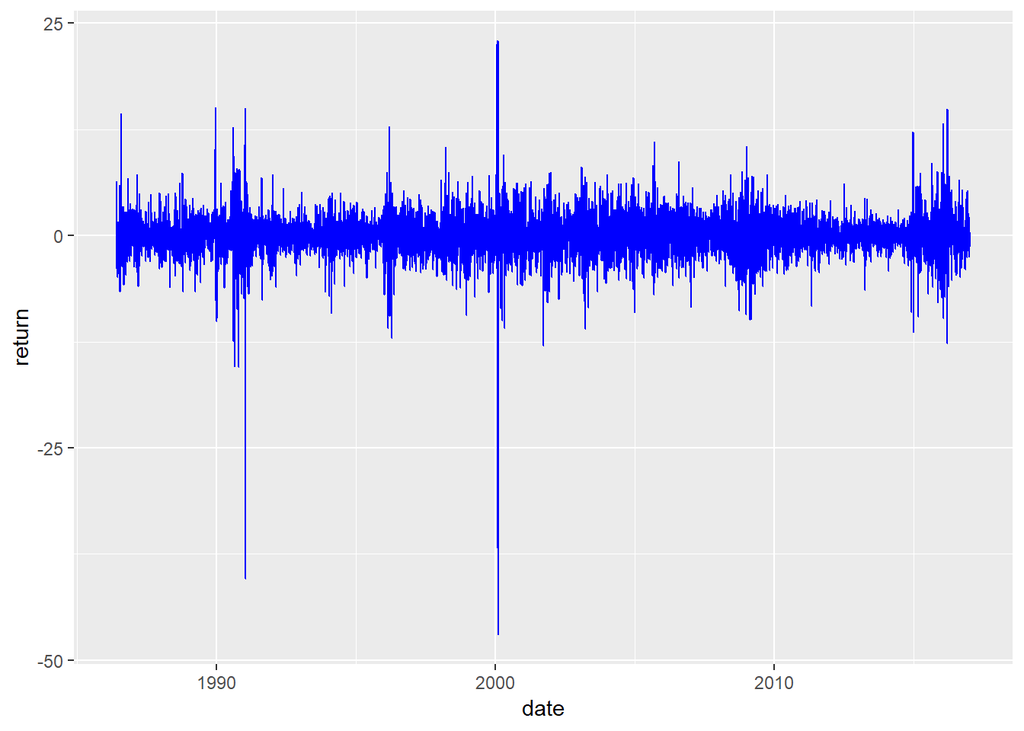

P1A1: The lowest outlier for negative returns is around -45%, and about 20% for positive returns. By taking the absolute value of the return we can view the overall deviation over time regardless of positive or negative returns. Notice that the around the .com crash (2000), and 9/11 (2001) as significant dates in the timeline. The overlay the initial return against the absolute value graph is then integrated into one concise graph.

By taking the absolute value of the return we can view the overal deviation over time. We can view this as ‘size’. Letâs try a bar graph of the absolute value of price rates. We use geom_bar to build this picture.

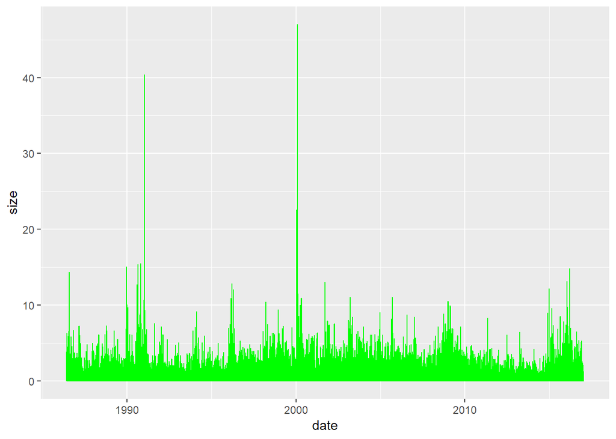

Letâs try a bar graph of the absolute value of price rates. We use geom_bar to build this picture.

We will now overlay the initial return against the absolute value graph.

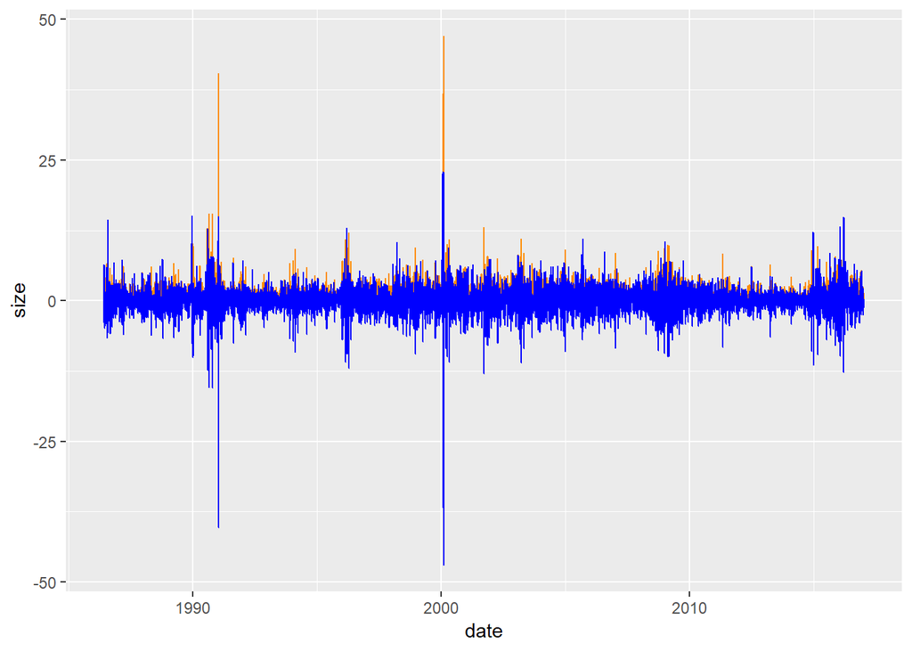

Notice from the mid 90’s there was a large increase in volatility in both return and size. Volatility slowed down around 2010, but has since risen to a large number. Graphically ggplot gives us a clear graphic view for our business question.

### Question 2

Letâs dig deeper and compute mean, standard deviation, etc. Load the data_moments() function. Run the function using the HO2.df$return subset of the data and write a knitr::kable() report.

| mean | std_dev | median | skewness | kurtosis |
| --- | --- | --- | --- | --- |
| 0.0179 | 2.5236 | 0 | -1.4353 | 38.2595 |

### Question 3

Letâs pivot size and return on direction. What is the average and range of returns by direction? How often might we view positive or negative movements in HO2?

```
##
## FALSE  TRUE
##  4039  3657
```

```
##
## FALSE  TRUE
##  3936  3760
```

```
##
## down same   up
## 3657  279 3760
```

```
##
## FALSE  TRUE
##  7417   279
```

| direction | return.avg | return.sd | quantile.5 | quantile.95 | percent |
| --- | --- | --- | --- | --- | --- |
| down | -1.77 | 1.99 | -4.78 | -0.19 | 47.52 |
| same | 0.00 | 0.00 | 0.00 | 0.00 | 3.63 |
| up | 1.76 | 1.75 | 0.18 | 4.82 | 48.86 |

[output not shown]

[output not shown]

P1A3: We begin our analysis by collecting the number of positive, negative, and zero returns this will result in 3,657 negative, 279 zero, and 3,760 positive returns. By percentage, this results in 47.52% negative, 3.63% zero, and 48.86% positive returns. This is almost an even split in the positive and negative returns in the price of oil that would make finding a trend in forecasting difficult. By average, the negative returns were -1.77% and the positive returns were 1.76% (we omit the zero returns as they will always be zero). Again this is close to an even split for gains, and by the frequency percentage compared to the average returns it shows that the overall change in oil prices will continue to be volatile but steadily increasing.

## Part 2: HO2 analysis

### Problem

We want to further characterize the distribution of up and down movements visually. Also we would like to repeat the analysis periodically for inclusion in management reports.

### Question 1

How can we show the differences in the shape of ups and downs in HO2, especially given our tolerance for risk? We can use the HO2.df data frame with ggplot2 and the cumulative relative frequency function stat_ecdf to begin to understand this data.

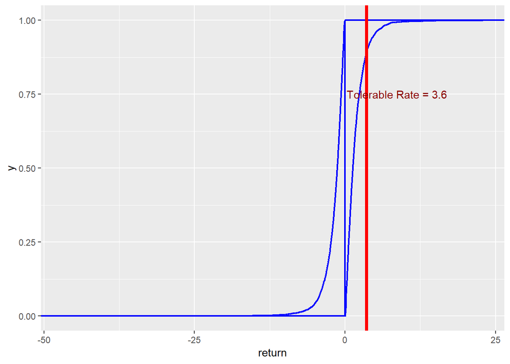

P2A1: The graph illustrates that our tolerable rate is 3.6%. This suggests that there is a 5% probability that the return will be greater than 3.6%. In New York Harborâs case, if the HO2 price increases more by 3.6% from the current price, additional approval (perhaps from management) is required. Additionally, the graph shows that if the return is a negative number (down) or zero, there is no probably that it will be greater than the threshold of 3.6%. This intuitively makes sense.

### Question 2

How can we regularly, and reliably, analyze HO2 price movements? For this requirement, letâs write a function similar to data_moments. Name this new function HO2_movement().

Test HO2_movement() with data and display results in a table with 2 decimal places.

| direction | return.avg | return.sd | quantile.5 | quantile.95 | percent |
| --- | --- | --- | --- | --- | --- |
| down | -1.77 | 1.99 | -4.78 | -0.19 | 47.52 |
| same | 0.00 | 0.00 | 0.00 | 0.00 | 3.63 |
| up | 1.76 | 1.75 | 0.18 | 4.82 | 48.86 |

P2A2: The results in the table can be used to create an upper and lower bound to help management predict with some level of certainty the rate of return and ultimately predict earnings. For example, if the return is a negative number (down) there is a 5% probability that it will be less than -4.78% (lower bound). On the other hand, if the return is a positive number (up) there is a 5% probability that it will be more than 4.82% (upper bound). These are good lower and upper bounds to have since the probability of the return being down or up are about split even at 47.52% and 48.86% (respectively). The remaining 3.63% probability is zero returns.

Morale: more work today (build the function) means less work tomorrow (write yet another report).

### Question 3

Suppose we wanted to simulate future movements in HO2 returns. What distribution might we use to run those scenarios? Here, letâs use the MASS packageâs fitdistr() function to find the optimal fit of the HO2 data to a parametric distribution. We will use the gamma distribution to simulate future heating oil #2 price scenarios.

```
## 'data.frame':    7696 obs. of  5 variables:
##  $ date     : Date, format: "1986-06-03" "1986-06-04" ...
##  $ price    : num  0.393 0.378 0.39 0.385 0.373 0.365 0.389 0.394 0.398 0.379 ...
##  $ return   : num  -2.26 -3.89 3.13 -1.29 -3.17 ...
##  $ size     : num  2.26 3.89 3.13 1.29 3.17 ...
##  $ direction: Factor w/ 3 levels "down","same",..: 1 1 3 1 1 1 3 3 3 1 ...
```

```
##      shape         rate
##   1.30753665   0.74299635
##  (0.02716171) (0.01872184)
```

```
##         m             s            df
##   -1.30565487    0.91307703    2.50894659
##  ( 0.02170850) ( 0.02061868) ( 0.12442996)
```

Here we are testing the data to see if the ‘t’ distribution would be the best fit to correllate to our data in forcasting potential outcomes.

```
##      shape         rate
##   1.31056202   0.73969342
##  (0.02761041) (0.01889467)
```

P2A3: You need to understand the function of fitting the data to the gamma distribution as well as some insights into what specifically the gamma distribution is calling. By fitting the data over the gamma and t distribution we can understand future returns with the data, but by understanding that values help you accept a distribution helps shape it.

Modern Applied Statistics with S. Fourth Edition Description fitdistr = Maximum-likelihood fitting of univariate distributions, allowing parameters to be held fixed if desired.

this model tries to fit the distribution can be predicted when we provide estimates of parameters.

in this case we use the gamma distribution to simulate future prices and then fit those values to the model.

## Conclusion

### Skills and Tools

some of the major packages used in the experiment. ggpplor2 - a package for visualizing data. In this case, data points over time series xtable - formats data into a table for easy production moments - supports creation of kurtosis and skewness dplyr - supports the shaping of data and data frames

### Business Remarks

This is a very good demonstration of how R can process very complex ideas and package them into a simple and effective visualization. The process only requires the user to determine what the question is and what algorithm they would like to use to illustrate or research the outcomes. In this case, a date time stamp and a value was utilized to create the given outputs.It unlikely the company will be able to predict when the next major event will occur that will significantly impact oil prices. So, to lessen their exposure the company may want to consider procuring another commodity that is negatively correlated with oil prices (i.e. hedge). They may also consider procuring multiple commodities to diversify their portfolio of products. The timing of purchase with known business cycle may also play a key role. Lastly, the combination of these options may also offset the high volatility of oil prices and may ultimately help the company improve their forecast earnings.

It unlikely the company will be able to predict when the next major event will occur that will significantly impact oil prices. So, to lessen their exposure the company may want to consider procuring another commodity that is negatively correlated with oil prices (i.e. hedge). They may also consider procuring multiple commodities to diversify their portfolio of products. The timing of purchase with known business cycle may also play a key role. Lastly, the combination of these options may also offset the high volatility of oil prices and may ultimately help the company improve their forecast earnings.